# Nouveautés de PostgreSQL 9.6

Workshop 9.6

Dalibo & Contributors

# Nouveautés de PostgreSQL 9.6

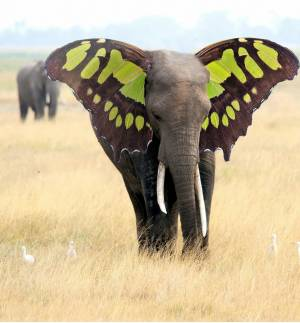

PostgreSQL

## Introduction

- Développement commencé en juin 2015
- Version Beta1 sortie le 12 mai 2016
- Sortie le 29 septembre 2016

## Au menu

- Performances
  - Administration
  - SQL
  - Monitoring
  - Régressions / changements
  - Et une petite ouverture vers le futur

## Performances

- Parallélisme :
  - parcours séquentiel
  - jointure
  - agrégation
- Index bloom
- Améliorations globales
  - checkpoint

### Parallélisme

- Avant la 9.6
  - une requête = un processus
  - pas de multithreading
- À partir de la 9.6
  - toujours pas de multithreading
  - toujours un processus pour une session
  - mais il peut être aidé par d’autres processus appelés **workers**

### Parallélisme : Opérations

- Parcours séquentiel
- Jointure
- Agrégation
- Uniquement les requêtes en lecture !

### Parallélisme : Paramètres 1/2

- `max_worker_processes` : Nombre max de background worker
- `max_parallel_workers_per_gather` : Nombre max de worker par gather
- `min_parallel_relation_size` : Taille min de la relation pour déclencher le parallélisme
  - Possibilité de forcer le nombre de worker possible pour une table :
  - `SET (parallel_workers = x)`

### Parallélisme : Paramètres 2/2

- `parallel_setup_cost` : Coût de la mise en place du parallélisme
- `parallel_tuple_cost` : Coût pour passer une ligne d’un worker au gather.

### Parcours séquentiel parallèle : explications 1

- Traitement des blocs par processus
- Compteur de blocs
  - Parallel Heap Scan Current Block
- Fonctionne en mode partiel
  - impossible à utiliser avec des données à trier

### Parcours séquentiel parallèle : exemple 1

- Exemple d’une table `test_parallel_little`
  - une seule colonne
  - non indexée
  - contenant 500 000 lignes

### Exemple 1 : jeu de tests

```sql
CREATE TABLE test_parallel_little (id int);

INSERT INTO test_parallel_little
  SELECT generate_series(0,500000);

SELECT n.nspname as "Schema",
       c.relname as "Name",
       pg_size_pretty(pg_table_size(c.oid)) as "Size"
FROM pg_class c
LEFT JOIN pg_namespace n ON n.oid=c.relnamespace
WHERE c.relname = 'test_parallel_little';


 Schema |     Name      |  Size
--------+---------------+--------
 public | test_parallel | 17 MB
```

### Exemple 1 : plan

```sql
EXPLAIN (ANALYZE, VERBOSE, BUFFERS)
SELECT * FROM test_parallel_little WHERE id = 12;

 Gather  (cost=1000.00..6889.58 rows=1 width=4)
         (actual time=30.300..30.385 rows=1 loops=1)
   Output: id
   Workers Planned: 1
   Workers Launched: 1
   Buffers: shared hit=2264
   ->  Parallel Seq Scan on public.test_parallel_little
       (cost=0.00..5889.48 rows=1 width=4)
       (actual time=18.568..27.957 rows=0 loops=2)
         Output: id
         Filter: (test_parallel_little.id = 124862)
         Rows Removed by Filter: 250000
         Buffers: shared hit=2213
         Worker 0: actual time=7.054..25.832 rows=1 loops=1
           Buffers: shared hit=978
 Planning time: 0.141 ms
 Execution time: 31.862 ms
(14 lignes)
```

### Parcours séquentiel parallèle : explications 2

- Taille de la table = T
- `min_parallel_relation_size` = S
- Si T < S, pas de worker
- Si T > S, un worker
- Si T > Sx3, un worker supplémentaire (2)
- Si T > Sx3x3, deux workers supplémentaires (3)
- Si T > Sx3^3, trois workers supplémentaires (4)

### Parcours séquentiel parallèle : exemple 2

- Exemple d’une table test_parallel
  - une seule colonne
  - non indéxée
  - contenant 5 000 000 lignes

### Exemple 2 : jeu de tests

```sql
CREATE TABLE test_parallel_little (id int);

INSERT INTO test_parallel_little
  SELECT generate_series(0,5000000);

SELECT n.nspname as "Schema",
       c.relname as "Name",
       pg_size_pretty(pg_table_size(c.oid)) as "Size"
FROM pg_class c
LEFT JOIN pg_namespace n ON n.oid=c.relnamespace
WHERE c.relname = 'test_parallel';

 Schema |     Name      |  Size
--------+---------------+--------
 public | test_parallel | 173 MB
```

### Exemple 2 : plan

```sql
EXPLAIN (ANALYZE, VERBOSE, BUFFERS)
SELECT * FROM test_parallel WHERE id=12;
 Gather  [...]
   Output: id
   Workers Planned: 3
   Workers Launched: 3
   Buffers: shared hit=5465 read=16812
   ->  Parallel Seq Scan on public.test_parallel  [...]
         Output: id
         Filter: (test_parallel.id = 124862)
         Rows Removed by Filter: 1250000
         Buffers: shared hit=5312 read=16812
         Worker 0: actual time=3.766..139.729 rows=1...
           Buffers: shared hit=1748 read=5466
         Worker 1: actual time=138.532..138.532 rows=0...
           Buffers: shared hit=812 read=2669
         Worker 2: actual time=138.508..138.508 rows=0...
           Buffers: shared hit=816 read=2683
 Planning time: 0.120 ms
 Execution time: 151.700 ms
(18 lignes)
```

### Parallélisme sur une jointure

```sql
EXPLAIN ANALYZE SELECT * FROM big b1 JOIN big b2 USING (id) WHERE b1.id < 400000;
 Gather  [...]
   Workers Planned: 2
   Workers Launched: 2
   ->  Hash Join  [...]
         Hash Cond: (b1.id = b2.id)
         Worker 0: [...]
         Worker 1: [...]
         ->  Parallel Seq Scan on b1  [...]
               Filter: (b1.id < 400000)
               Rows Removed by Filter: 16903334
               Worker 0: [...]
               Worker 1: [...]
         ->  Hash  [...]
               Buckets: 4194304  Batches: 1  Memory Usage: 141753kB
               Worker 0: [...]
               Worker 1: [...]
               ->  Seq Scan on public.t3  [...]
                     Worker 0: [...]
                     Worker 1: [...]
```

### Parallélisme sur une agrégation

```sql
EXPLAIN (ANALYZE)
SELECT count(*), min(C1), max(C1) FROM t1;

                           QUERY PLAN
---------------------------------------------------------------------
 Finalize Aggregate
 (actual time=1766.820..1766.820 rows=1 loops=1)
   ->  Gather
       (actual time=1766.767..1766.799 rows=3 loops=1)
         Workers Planned: 2
         Workers Launched: 2
         ->  Partial Aggregate
             (actual time=1765.236..1765.236 rows=1 loops=3)
               ->  Parallel Seq Scan on t1
                   (actual time=0.021..862.430 rows=6666667
                    loops=3)
 Planning time: 0.072 ms
 Execution time: 1769.164 ms
(8 rows)
```

### Parallélisation : limitations

- Les fonction doivent être *Parallel Safe*
- Il faut indiquer au planificateur qu’une fonction peut être utilisée :
  - Dans un gather et worker : `PARALLEL SAFE`
  - Dans un gather uniquement `RESTRICTED`
  - Ne peut pas être utilisée pour la parallélisation : `PARALLEL UNSAFE`
- Pas de parallélisation pour :
  - Requête effectuant des écritures ou posant des verrous
  - Une requête qui pourrait être suspendue pendant son exécution. Exemple `CURSOR`
  - Une sous requête exécutée dans une requête déjà parallélisée.
  - Niveau d’isolation *serializable*

### Index bloom

Infrastructure pour de nouvelles méthodes d’accès sous forme d’extensions.

- Premier exemple : les index **bloom**
  - extension
  - basés sur la probabilité de présence, avec perte
  - plus petits mais impliquent un accès à la table
  - permettent d’avoir un index pour des **recherches multicritères** si les btree sont impraticables ou trop gros
  - égalité seulement pour entiers et chaînes

### Divers - Checkpoint

- Avant
  - écriture aléatoire car blocs lus dans l’ordre du cache
- Après
  - parcours intégral des blocs pour trier et mutualiser les écritures
- `checkpoint_flush_after` : Flush les données sur disques tous les X octets
  - Permet d’éviter le tuning des options `dirty_background_*` du kernel

### Divers - Tri

- Gain sur les opérations de tris
  - `replacement_sort_tuples`
  - Meilleure utilisation du cache des CPU

## Administration

- Gestion des slots de réplication pour `pg_basebackup`
- Sauvegardes à chaud concurrentes
- Réplication synchrone sur plusieurs nœuds
- Amélioration des Foreign Data Wrapper
- Amélioration du freeze
  - et nouvelle extension : `pg_visibility`
- Divers
  - `pg_config`, `pg_control*`

### Slots de réplication pour pg_basebackup

- Nouvelle option
  - `-S slotname` ou `--slot=slotname`
  - s’utilise obligatoirement avec `-X stream`
- Plus besoin d’archivage pour créer un serveur secondaire
  - sans aucun risque

### Sauvegardes à chaud concurrentes

- Déjà possible avec `pg_basebackup`…
  - mais pas en manuel avec `pg_start_backup()`
- Nouvelle API
- `pg_start_backup()` et `pg_stop_backup()`
  - paramètre supplémentaire pour utilisation concurrente
  - par défaut à false
- Contraintes lorsqu’on utilise l’option concurrente
  - maintien de la session
  - plus de `backup_label`
  - => Privilégier des outils supportant cette fonctionnalité.

### Réplication synchrone, l’existant

- 9.0, réplication asynchrone
- 9.1, réplication synchrone
  - plusieurs esclaves potentiellement synchrones
  - mais un seul synchrone à un instant t

### synchronous_commit

- Positionné à ON par défaut
- Soit le client, soit le maître
- Les modifications sont écrites dans les WAL avant d’envoyer la confirmation
- Nouvelle valeur :
  - `remote_apply`

### Réplication synchrone sur plusieurs nœuds

- Plusieurs serveurs synchrones
- Configuration
  - synchronous_standby_names = ‘N (liste serveurs)’
  - N = nombre serveurs synchrones
- Contraintes
  - latence induite par la validation des transactions sur plusieurs esclaves
  - requêtes en attente sur le primaire s’il y a moins de N serveurs synchrones disponibles

### Foreign Data Wrapper

- Norme SQL/MED
- Interroger des données externes.
- Données externes présentées comme des tables
- Attention aux performances !

### FDW : jeu de tests

```sql
CREATE TABLE t1 (id integer);
INSERT INTO t1 SELECT generate_series(1, 10000000);
CREATE INDEX ON t1(id);

CREATE EXTENSION postgres_fdw;

CREATE SERVER ailleurs FOREIGN DATA WRAPPER postgres_fdw;

CREATE USER MAPPING FOR postgres SERVER ailleurs;

CREATE FOREIGN TABLE ft1(id integer)
  SERVER ailleurs
  OPTIONS (table_name 't1');
```

### FDW : Nouveautés

- SORT pushdown
  - exécution du tri sur le serveur distant
- JOIN pushdown
  - exécution de la jointure sur le serveur distant

### FDW : tri en 9.5

```sql
EXPLAIN (ANALYZE, VERBOSE, COSTS off)
SELECT * FROM ft1 ORDER BY id ;

                          QUERY PLAN
--------------------------------------------------------------
 Sort (actual time=9452.057..10129.182 rows=10000000 loops=1)
   Output: id
   Sort Key: ft1.id
   Sort Method: external sort  Disk: 136856kB
   ->  Foreign Scan on public.ft1
       (actual time=1.064..5981.536 rows=10000000 loops=1)
         Output: id
         Remote SQL: SELECT id FROM public.t1
 Planning time: 0.131 ms
 Execution time: 10425.730 ms
(9 rows)
```

### FDW : tri en 9.6

```sql
EXPLAIN (ANALYZE, VERBOSE, COSTS off)
SELECT * FROM ft1 ORDER BY id;

                      QUERY PLAN
-----------------------------------------------------
 Foreign Scan on public.ft1
 (actual time=2.092..7438.416 rows=10000000 loops=1)
   Output: id
   Remote SQL: SELECT id FROM public.t1
               ORDER BY id ASC NULLS LAST
 Planning time: 0.168 ms
 Execution time: 7748.122 ms
(5 rows)
```

### FDW : jointure en 9.5

```sql
EXPLAIN (VERBOSE, ANALYZE)
SELECT * FROM table1_distante
JOIN table2_distante ON table1_distante.id = table2_distante.id
WHERE table2_distante.id = 1;

                      QUERY PLAN
-----------------------------------------------------------
 Nested Loop  [...]
   Output: table1_distante.id, table1_distante.bla,
           table2_distante.id, table2_distante.bli
   ->  Foreign Scan on public.table1_distante  [...]
         Output: table1_distante.id, table1_distante.bla
         Remote SQL: SELECT id, bla FROM public.table1
                     WHERE ((id = 1))
   ->  Foreign Scan on public.table2_distante  [...]
         Output: table2_distante.id, table2_distante.bli
         Remote SQL: SELECT id, bli FROM public.table2
                     WHERE ((id = 1))
 Planning time: 0.217 ms
 Execution time: 65.616 ms
```

### FDW : jointure en 9.6

```sql
EXPLAIN (VERBOSE, ANALYZE)
SELECT * FROM table1_distante
JOIN table2_distante
  ON table1_distante.id=table2_distante.id
WHERE table2_distante.id = 1;

                      QUERY PLAN
--------------------------------------------------------
 Foreign Scan  [...]
   Output: table1_distante.id, table1_distante.bla,
           table2_distante.id, table2_distante.bli
   Relations: (public.table1_distante)
              INNER JOIN (public.table2_distante)
   Remote SQL: SELECT r1.id, r1.bla, r2.id, r2.bli
               FROM (public.table1 r1
               INNER JOIN public.table2 r2
                  ON (((r2.id = 1)) AND ((r1.id = 1))))
 Planning time: 0.170 ms
 Execution time: 2.299 ms
```

### FREEZE

- Amélioration de la fonction de gel des données
- pg_visibility(oid)
  - blkno
  - all_visible
  - all_frozen
  - pd_all_visible

### pg_config, pg_control

- Outil pg_config
  - informations de compilation
- Outil pg_controldata
  - informations du fichier pg_control
- Informations uniquement disponibles sur la ligne de commande avant la 9.6
- Maintenant disponibles aussi via l’interface SQL
  - vue pg_config
  - fonctions pg_control_system(), pg_control_init(), pg_control_checkpoint() et pg_control_recovery()

## SQL

- Recherche plein-texte pour les phrases
- Option CASCADE pour les extensions
- Pivotage des résultats
- Autres nouveautés
  - fonction mathématiques
  - `jsonb_insert()`

### Recherche plein-texte pour les phrases

- FTS disponible dans PostgreSQL depuis la version 8.3
- Opérateurs disponibles jusqu’à présent
  - ET logique : &
  - OU logique : |
  - NON logique : !
- Nouvel opérateur :
  - Succession : <->
  - Position dans la phrase : (où N est un entier représentant le nombre de mot séparant les deux motifs)

### Ajout de l’option CASCADE pour les extensions

- Avant la version 9.6 `postgres=# CREATE EXTENSION ltree_plpythonu; ERREUR: l'extension « ltree » requise n'est pas installée`
- Après la version 9.6 `postgres=# CREATE EXTENSION ltree_plpythonu CASCADE; NOTICE: installing required extension "ltree" NOTICE: installing required extension "plpythonu" CREATE EXTENSION`

### Pivotage des résultats

- `\crosstabview [ colV [ colH [ colD [ sortcolH ] ] ] ]`
- Exécute le contenu du tampon de requête
  - la requête doit renvoyer au moins 3 colonnes
- Affiche le résultat dans une grille croisée
  - colV, en-tête vertical
  - colH, en-tête horizontal
  - colD, contenu à afficher dans le tableau
  - sortColH, colonne de tri pour l’en-tête horizontal

### Autres nouveautés

- Amélioration des performances globales pour plusieurs fonctions mathématiques
  - ln() / log() / exp() / pow()
- Ajout des fonctions
  - sind() / cosd() / tand()

## Monitoring

- Nouvelles colonnes dans `pg_stat_activity`
- Nouvelle fonction `pg_blocking_pid()`
- Nouvelle vue `pg_stat_progress_vacuum`

### Vue pg_stat_activity, pg_blocking_pids()

- Avant la 9.6
  - identification complexe d’une requête bloquante
  - et de la raison du blocage
- Ajout de la fonction `pg_blocking_pids()`
- modification de la colonne waiting en deux colonnes
  - wait_event
  - wait_event_type

### Fonction pg_blocking_pids()

- Avant la 9.6
  - requête complexe pour trouver la session bloquante
  - voire collection de requêtes
- Depuis la 9.6
  - fonction `pg_blocking_pids()`

### pg_stat_progress_vacuum

- Intégration d’une API pour le suivi de progression d’une commande
- Utilisation de cette API pour VACUUM
- Vue pg_stat_progress_vacuum
  - nombreuses informations sur la progression d’une opération VACUUM

## Régressions / changements

- Il n’est plus possible de créer des rôles commençant par `pg_*`
- L’option -c de psql (exécution de commande) n’active plus –no-psqlrc
- L’option -t de `pg_restore` ne correspond plus seulement aux tables
  - mais à tous types de relations
- Niveaux `archive` et `hot_standby` n’existent plus pour `wal_level`.
  - Remplacés par un niveau `replica` <=> `hot_standby`

## Futur

- Version 10, en septembre/octobre 2017
- Beta 1 depuis le 18 mai
- Fonctionnalités majeures
  - réplication logique
  - partitionnement natif de table (suite et liste)
  - amélioration du partitionnement (parcours d’index, de bitmap, jointure par tri)
  - quorum pour la réplication synchrone